# Linux-Basics-DECODE T32 Training Program

Sujith Manavalan

smanavalan@unmc.edu

2024-08-20

Adapted from: Software Carpentry repo (https://eharstad.github.io/shell-novice/)

# Introduction

Here is a list of the modules we will cover:

| **Module Number** | **Module Name** |
| --- | --- |
| Module 1 | Getting Started with HCC |
| Module 2 | File Navigation |
| Module 3 | Creating & Deleting Things |
| Module 4 | Pipes and Filters |
| Module 5 | Short Intro to Loops |
| Module 6 | grep Command (only setting up the required files) |

## Module 1 : Getting Started with HCC

```bash
ssh username@swan.unl.edu #ssh login
```

SSH (Secure Shell) is a network protocol used to securely access and manage remote servers and systems. Commonly used for remote command-line login and execution of commands on a remote machine.

**Intro to HCC**

https://hcc.unl.edu/docs/intro/

**HCC SWAN Resource Capabilities**

```
Cluster Name: Swan
Total Nodes: 168
Processor: Intel Xeon Gold 6348
CPUs per Node: 2
Cores per Node: 56
Memory per Node: 256GB
High-Memory Nodes: 2 nodes with 2000GB
```

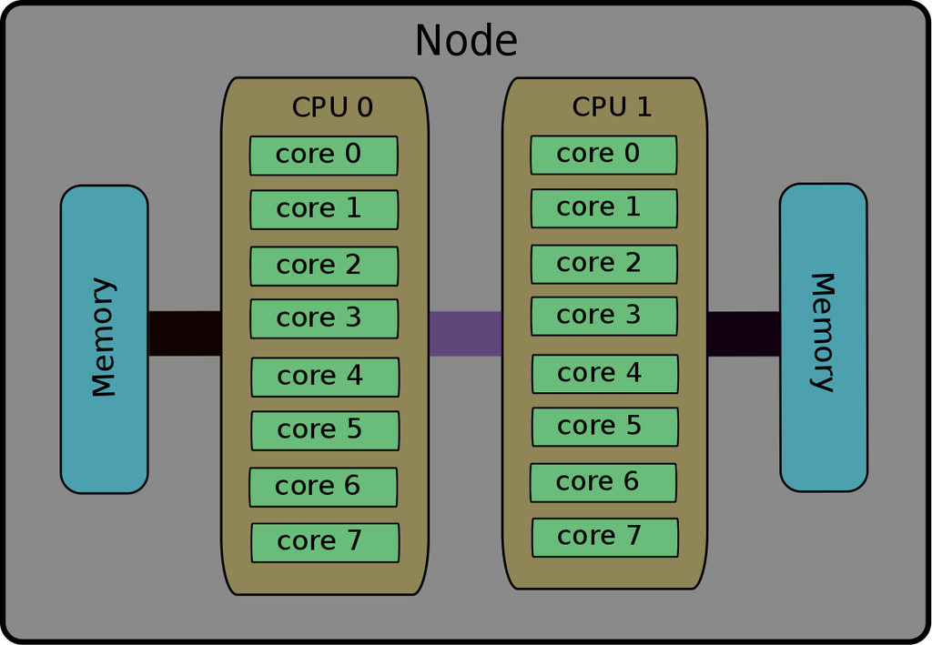

**Understanding CLI(command line interface)**

1. What is a Command-Line Interface (CLI)?

Imagine talking to your computer by typing out commands instead of clicking on icons and menus like you do in a regular desktop environment. That’s what the CLI is— a text-based way to interact with your computer.  
Unlike the Graphical User Interface (GUI), where you use a mouse to navigate, the CLI requires you to type specific instructions to get things done.

2. What is a Shell?

The shell is like your computer’s translator. When you type a command, the shell takes your input and tells the computer what to do. Think of it as the middleman between you and the computer’s operating system.  
There are different types of shells, but one of the most common in Linux is called Bash (which stands for “Bourne Again SHell”). Bash makes it easier for you to interact with the system by providing helpful features like command history, scripting, and more.

3. What is REPL (Read-Evaluate-Print Loop)? The shell operates in a cycle known as REPL, which stands for Read-Evaluate-Print Loop.  
   Here’s how it works:
- Read: You type a command, and the shell reads it.
- Evaluate: The shell interprets what you’ve typed and executes it.
- Print: The shell shows you the result of the command.
- Loop: This cycle repeats, meaning you can keep typing and running commands as long as you need.

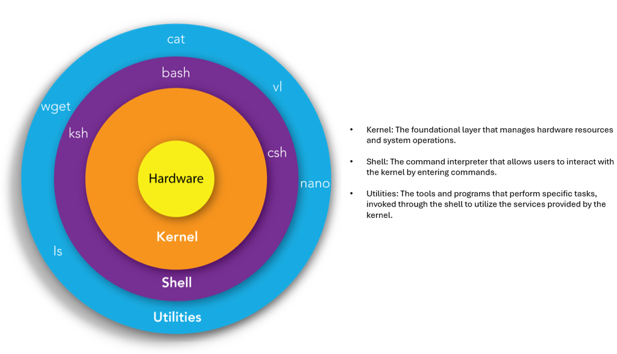

**Intro to HCC SWAN File system**

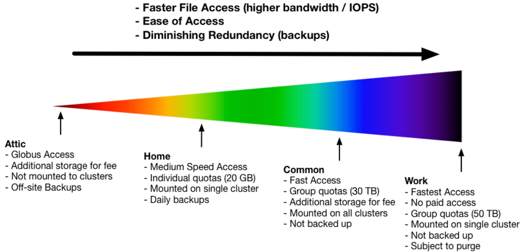

source : https://hcc.unl.edu/docs/handling_data/

For this tutorial, we will be using the `/home` directory (Note: The home directory has only 20GB of storage, so please avoid keeping large files in `/home`. Move them to `/work` instead.)

`cd` stands for change directory. In Unix/Linux operating systems, the `cd` command is used to change the current working directory to a different directory specified by the user.

Basic syntax of `cd` command is

```bash
cd /path/to/directory
```

To navigate to the `/home` directory use any of the following commands

Kindly note: the first two commands will work as expected if your primary group is `t32decode`

```bash
cd #cd defaults to home directory
```

```bash
cd ~
```

`$HOME` is an environment variable that stores the absolute path to the current user’s home directory

```bash
cd $HOME
```

Shell expansion:

In both cases (cd ~ and cd $HOME), the shell performs an expansion before executing the command:

Tilde expansion cd `~`: The shell expands the special character `~` to the path of the home directory. Variable expansion `cd $HOME`: The shell expands $HOME to the actual path stored in the environment variable.

Alternatively, use the following command to *explicitly navigate* to the `/home` directory:

```bash
cd /home/t32decode/username/
```

We will proceed with the further tutorial using the `/home` directory as the starting point.

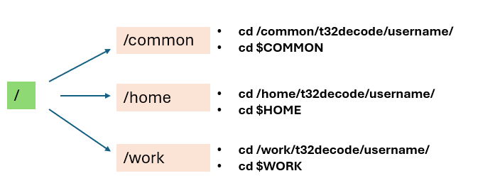

Lets check the OS in HCC

```bash
hostnamectl
```

[output not shown]

`AlmaLinux` is a free and open-source Linux distribution that is a direct replacement for CentOS

### Linux/Unix and its Flavours

[figure not shown]

source: https://medium.com/@kunalbarot3188/linux-history-and-fundamentals-706dc54fc6ee

### Getting Help in Linux/Unix

```bash
man ls
```

- `man`
- Opens the manual (man) page for detailed documentation of a command.
- Example: `man ls` shows the full manual for the `ls` command.

Tips for moving around the manual page

- `Spacebar`: Move forward one page in the manual.
- `B`: Move backward one page in the manual.
- `Q`: Quit the manual viewer.

```bash
ls --help
```

- `--help`
- Displays a brief summary of the command’s usage and options.
- Example: `ls --help` gives a quick overview of how to use `ls`.

```bash
whatis ls
```

- `whatis`
- Provides a one-line description of what the command does.
- Example: `whatis ls` shows a short explanation of `ls`.

```
ls (1)               - list directory contents
```

## Module 2: File Navigation

1. `whoami`

The dollar sign is a prompt, which shows us that the shell is waiting for input; your shell may use a different character as a prompt and may add information before the prompt.

Type the command `whoami`, then press the Enter key (Mac OS = Return) to send the command to the shell. The command’s output is the ID of the current user, i.e., it shows us who the shell thinks we are:

```bash
whoami
```

Next, let’s find out where we are by running a command called `pwd` (which stands for “print working directory”). At any moment, our *current working directory* is our current default directory, i.e., the directory that the computer assumes we want to run commands in unless we explicitly specify something else.

`pwd` command

```bash
pwd
```

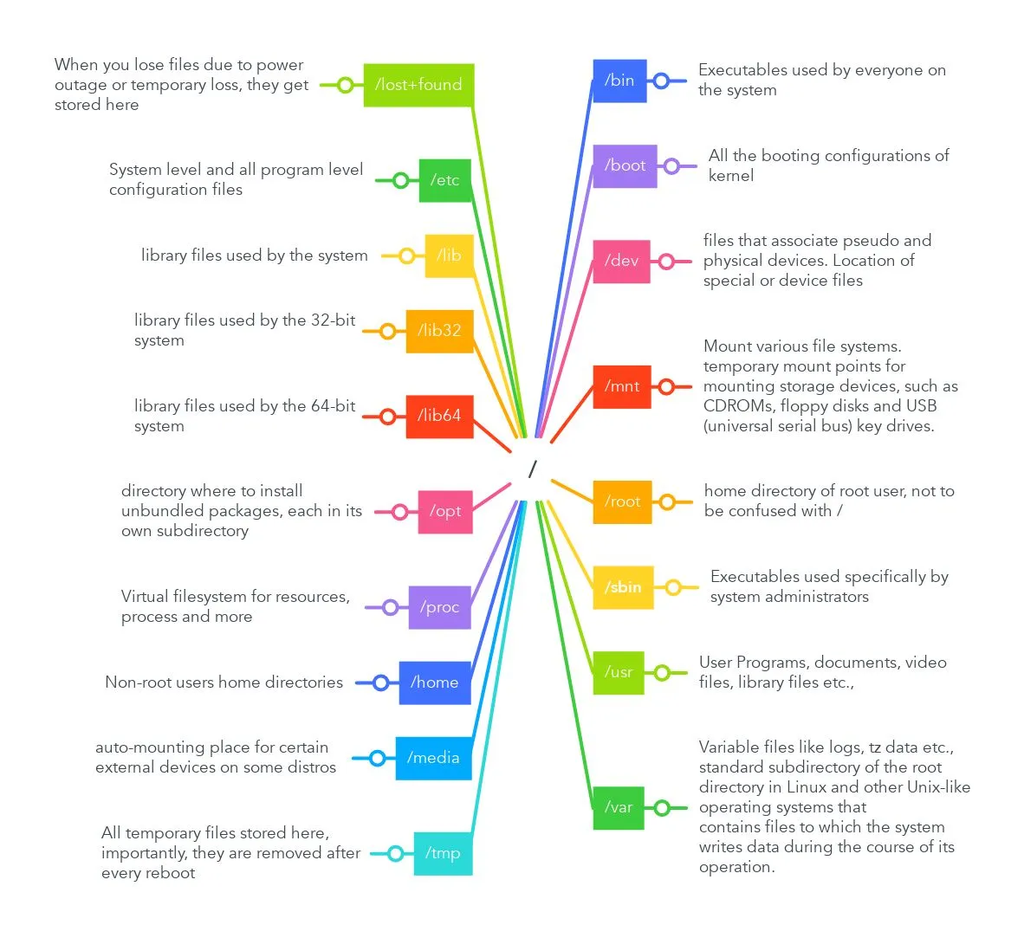

source : https://medium.com/@ojovbo.nelson/the-linux-file-system-471033ab42ea

*Directories in the Linux Root Filesystem in HCC*

To view the directories and files present in the root directory (`/`) of the HCC system, we can use the `ls` command. The root directory is the top-level directory in the filesystem hierarchy.

You can list the contents of the root directory using the following command:

```bash
ls /
```

```
bin  boot  common  cvmfs  dev  etc  home  lib  lib64  lustre  media  mnt  opt  proc  rgi  root  run  sbin  scratch  srv  sys  tmp  usr  util  var  work
```

1. `/home`

The `/home` directory is where user-specific files and directories are stored. Each user has a subdirectory within `/home`, such as `/home/john` for a user named John. This is where personal documents, configurations, and other data specific to the user are kept.

2. `/work`

The `/work` directory is typically used for project-specific or work-related data. It’s a custom directory that organizations or users create to store files related to specific tasks, projects, or ongoing work.

3. `/usr`

The `/usr` directory is where user applications and utilities are stored. It includes subdirectories like `/usr/bin` for user executables and `/usr/lib` for libraries.

```bash
 which pwd
```

```
/usr/bin/pwd
```

For the following lessons, you will need to download a set of files which emulates the home filesystem of a user named Nelle.

The `cd` command in Linux stands for “Change Directory.” It’s a way to move around in the computer’s file system

Note : Before running the command below ensure that you are in your user home directory. use `cd ~` or `cd` or absolute path  
`cd /home/t32decode/<your-username>/`. Please run `pwd` to you should be getting `/home/t32decode/<your-username>`

We will use `git clone` command to clone the repository. before proceeding let’s check the location of git command using `which`

```bash
which git
```

```
/util/opt/anaconda/deployed-conda-envs/packages/git/envs/git-2.39.3/bin/git
```

```bash
cd ~
git clone https://github.com/eharstad/filesystem.git  #cloning from git repo
```

```
Cloning into 'filesystem'...
remote: Enumerating objects: 212, done.
remote: Total 212 (delta 0), reused 0 (delta 0), pack-reused 212 (from 1)
Receiving objects: 100% (212/212), 121.68 KiB | 1.90 MiB/s, done.
Resolving deltas: 100% (109/109), done.
```

Lets explore the contents of the file system

```bash
ls                    # list contents in the $HOME directory
```

You should be able to view a directory named `filesystem`

```bash
ls filesystem/Users/
cd filesystem/Users/nelle
```

```
imhotep  larry  nelle
```

3. `ls`

`ls` prints the names of the files and directories in the current directory in alphabetical order, arranged neatly into columns. We can make its output more comprehensible by using the flag `-F`, which tells ls to add a trailing / to the names of directories:

```bash
ls
```

```
creatures  molecules           pizza.cfg
data       north-pacific-gyre  solar.pdf
Desktop    notes.txt           writing
```

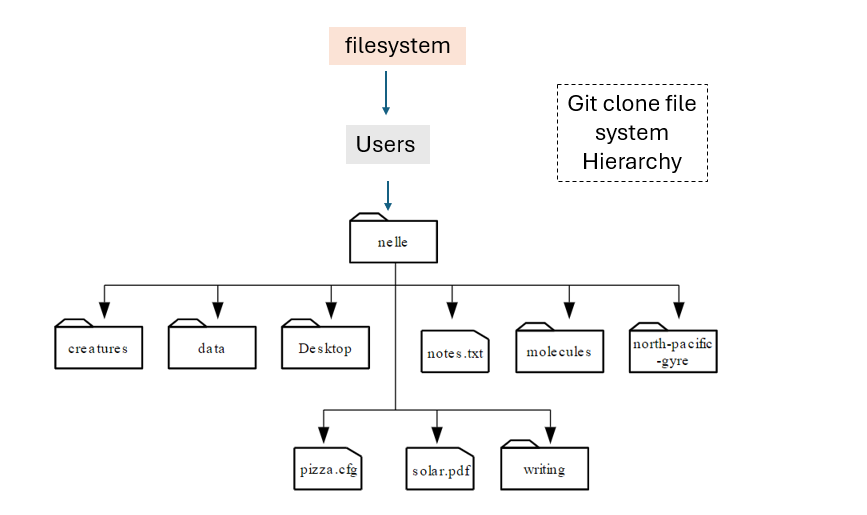

source : https://eharstad.github.io/shell-novice/01-filedir.html

Lets try `ls` with the `-F` flag/argument

```bash
ls -F
```

```
creatures/  molecules/           pizza.cfg
data/       north-pacific-gyre/  solar.pdf
Desktop/    notes.txt            writing/
```

Now let’s take a look at what’s in Nelle’s data directory by running `ls -F data`, i.e., the command `ls` with the arguments `-F` and `data`. The second argument (`data`) tells `ls` that we want a listing directory `data`:

```bash
ls -F data
```

```
amino-acids.txt   elements/     morse.txt
pdb/              planets.txt   sunspot.txt
```

*How many files and Sub-directories are present ???*

Notice : `data` doesn’t begin with a slash because it’s a relative path, i.e., it tells ls how to find something from where we are, rather than from the root of the file system.

*What is an argument/flag/option ??*

An argument is a value provided to a command to modify its behavior.

`ls` is the command used to list directory contents. `-F` is an argument (specifically, an option or flag) that tells `ls` to add a character to the end of each listed item, indicating its type (e.g., / for directories)

*what if we run ls -F /data (with a leading slash) ??*

```bash
ls -F /data # list contents of /data directory present in root
```

```
ls: cannot access '/data': No such file or directory
```

```bash
ls -F / # list contents of the root (/) directory with file type indicators
```

[output not shown]

- `/` (Slash):

  Indicates a Directory: When a name ends with a `/`, it means that the item is a directory (folder) where other files and directories are stored.

  Example: `home/`, `usr/`
- `@` (At Symbol):

  Indicates a Symbolic Link: A symbolic link (symlink) is like a shortcut or alias to another file or directory. The `@` indicates that the item is a link pointing to another location.

  Example: `bin@`, `lib64@`
- `*` (Asterisk):

  Indicates an Executable File: If a name ends with an `*`, it means that the file is executable, meaning it can be run as a program or script.

  Example: `init*`

```bash
ls -F
cd data
```

We can use `cd` followed by a directory name to change our working directory. `cd` stands for “change directory”.

where are we now ??

```bash
pwd
```

we should get an absolute path ending with `filesystem/Users/nelle/data`

```
/home/t32decode//filesystem/Users/nelle/data
```

We now know how to go down the directory tree: how do we go up? We could use an absolute path:but it’s almost always simpler to use `cd ..` to go up one level:

```bash
cd ..
pwd
```

`..` is a special directory name meaning parent of the current directory. if we run pwd after running `cd ..`, we’re back in `/xx/xxx/filesystem/Users/nelle/`

Kindly note: xxx represents the absolute path to the location of the nelle directory. This path may differ for each user because the home directory varies from one user to another.

Considering that all the users are currently in the directory `nelle` we will further explore the file hierarchy

The special directory `..` doesn’t usually show up when we run ls. If we want to display it, we can give ls the `-a` flag:

```bash
ls -F -a
```

```
./                  creatures/          notes.txt
../                 data/               pizza.cfg
.bash_profile       molecules/          solar.pdf
Desktop/            north-pacific-gyre/ writing/
```

`-a` stands for “show all”; it forces `ls` to show us file and directory names that begin with `.`, such as `..` (which, if we’re in `xx/Users/nelle`, refers to the `/Users directory`). As you can see, it also displays another special directory that’s just called `.`, which means “the current working directory”. It may seem redundant to have a name for it, but we’ll see some uses for it soon.

Finally, we also see a file called `.bash_profile`. This file usually contains settings to customize the shell (terminal).

Next discuss `tab autocompletion`

assuming everyone is in the directory named `nelle`

```bash
ls north-pacific-gyre/2012-07-03/
```

```
goodiff         NENE01729B.txt  NENE01751B.txt  NENE01843B.txt  NENE01978B.txt  NENE02040B.txt  NENE02043B.txt
goostats        NENE01736A.txt  NENE01812A.txt  NENE01971Z.txt  NENE02018B.txt  NENE02040Z.txt
NENE01729A.txt  NENE01751A.txt  NENE01843A.txt  NENE01978A.txt  NENE02040A.txt  NENE02043A.txt
```

This is a lot to type, you can let the shell do most of the work. If you type:

```bash
ls nor # and press tab
```

and then presses tab, the shell automatically completes the directory name for you:

If you presses tab again, Bash will add `2012-07-03/` to the command, since it’s the only possible completion. pressing tab twice brings up a list of all the files inside `2012-07-03`, and so on. This is called `tab completion`, and we will see it in many other tools as we go on.

The `tree` command is used to display the directory structure in a tree-like format. It recursively lists all the files and directories, making it easy to see how directories are nested within each other. ( Kindly note : `tree` command may not be supported in some systems)

```bash
ls -F
cd writing/
tree
```

[output not shown]

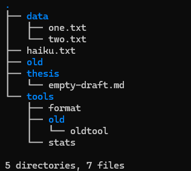

Lets compare `tree` output with `ls -F` output

```bash
ls -F
```

Limit the Depth of the Tree:

You can use the `-L` option to limit the depth of the tree. For example, to limit `tree` to just one level, you would use:

```bash
tree -L 1
```

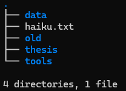

tree with -L flag

*Text adventure to help learn Linux commands and file navigation.*

#### Game time

`https://web.mit.edu/mprat/Public/web/Terminus/Web/main.html`

#### Quizz time

Filesystem for Challenge Questions

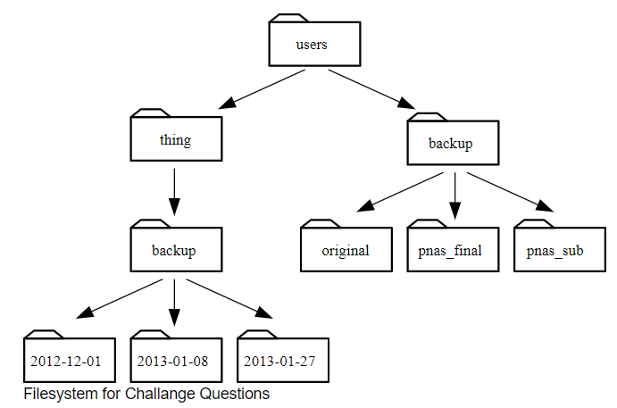

If `pwd` displays `/users/thing`, what will `ls ../backup` display?

1. ../backup: No such file or directory
2. 2012-12-01 2013-01-08 2013-01-27
3. 2012-12-01/ 2013-01-08/ 2013-01-27/
4. original pnas_final pnas_sub

hint : `..` moves up one level in the directory structure, so from /users/thing to /users.

#### Detailed View of the directories

1. Using ls command

To check size of files in a directory and permsion as well as time stamp, you can use the `ls` command with the `-lh` options

The -l flag is for long listing and -h flag is for Human-Readable Format

```bash
cd ~/filesystem/Users/nelle/ # this command will take you to the filesystem we have created using git clone
ls -lh
```

```
total 53K
drwxr-xr-x 2 sujith unmc_gudalab   3 Aug 20 22:39 Desktop
drwxr-xr-x 2 sujith unmc_gudalab   4 Aug 20 22:39 creatures
drwxr-xr-x 4 sujith unmc_gudalab  10 Aug 20 22:39 data
drwxr-xr-x 2 sujith unmc_gudalab   8 Aug 20 22:39 molecules
drwxr-xr-x 3 sujith unmc_gudalab   3 Aug 20 22:39 north-pacific-gyre
-rw-r--r-- 1 sujith unmc_gudalab  86 Aug 20 22:39 notes.txt
-rw-r--r-- 1 sujith unmc_gudalab  32 Aug 20 22:39 pizza.cfg
-rw-r--r-- 1 sujith unmc_gudalab 22K Aug 20 22:39 solar.pdf
drwxr-xr-x 6 sujith unmc_gudalab   7 Aug 20 22:39 writing
```

lets explore the permission string

- d or -: Indicates file type (d for directory, - for regular file).
- rwxr-xr-x: Represents permissions for the owner, group, and others.
- Categories of Users
  - Owner (User): The first three characters.
  - Group: The next three characters.
  - Others: The last three characters.
  - r (read): View file contents or list directory.
  - w (write): Modify file or directory contents.
  - x (execute): Run the file or access the directory.
2. Using du command `du` command stands for disk usage. It is used to estimate and report the amount of disk space used by files and directories. The flag `-s`summarizes the total size, the `-h` flag makes the size human-readable. `*` is a wildcard character that represents all files and directories in the current directory.

```bash
du -sh *
```

```
1.0K    Desktop
9.5K    creatures
752K    data
36K     molecules
95K     north-pacific-gyre
512     notes.txt
512     pizza.cfg
25K     solar.pdf
35K     writing
```

## Module 3 : Creating & Delete Things

We now know how to explore files and directories, but how do we create them in the first place? Let’s go back to Nelle’s home directory, `cd ~/filesystem/Users/nelle`, and use `ls -F` to see what it contains:

```bash
cd ~/filesystem/Users/nelle
ls -F
```

```
creatures/  molecules/           pizza.cfg
data/       north-pacific-gyre/  solar.pdf
Desktop/    notes.txt            writing/
```

Let’s create a new directory called thesis using the command mkdir thesis (which has no output):

```bash
mkdir thesis
```

`mkdir` means “make directory”. Since thesis is a relative path (i.e., doesn’t have a leading slash), the new directory is created in the current working directory, lets verify it

```bash
ls -F
```

```
Desktop/  creatures/  data/  molecules/  north-pacific-gyre/
notes.txt  pizza.cfg  solar.pdf  thesis/  writing/
```

However, there’s nothing in it yet:

```bash
ls -F thesis
```

One of the simplest ways to create an empty file is via the `touch` command. Change the working directory to `thesis` using `cd`, then touch an empty file called `draft.txt`:

```bash
cd thesis
touch draft.txt # create an empty file
```

If we check the directory contents now,

```bash
ls -F .  # or ls -F
```

```
draft.txt
```

Lets remove the text file using `rm`, the command used to remove files and directories . We will use `-i` flag to for removal confirmation.

```bash
rm -i draft.txt
```

```
rm: remove regular empty file 'draft.txt'? y
```

To proceed with the deletion, you should type y (for “yes”) and press Enter.

lets confirm the deletion of the file using `ls`

```bash
ls
```

Now lets run a text editor called Nano to create a file called draft.txt( this is an another way to create a bew file)

```bash
nano draft.txt
```

Let’s type in a few lines of text, then use `Control-O` to write our data to disk (press enter):

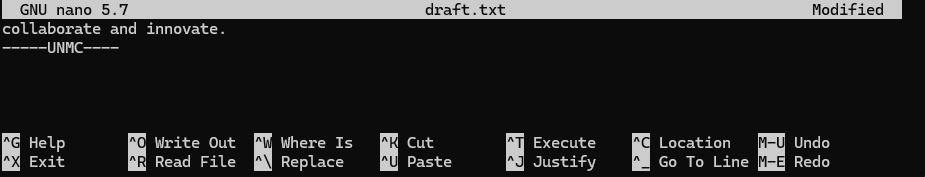

Nano in action

Once our file is saved, we can use `Control-X` to quit the editor and return to the shell. (Unix documentation often uses the shorthand `^A` to mean “control-A”.).

```
Press Control-O (^O) to save your file.
Press Control-X (^X) to exit the editor.
```

nano doesn’t leave any output on the screen after it exits, but `ls` now shows that we have created a file called `draft.txt`:

```bash
ls
```

```
draft.txt
```

Let’s tidy up by running `rm draft.txt`:

```bash
rm draft.txt
```

Important: `Deleting is forever`

The Unix shell doesn’t have a trash bin that we can recover deleted files from . Instead, when we delete files, they are unhooked from the file system so that their storage space on disk can be recycled.

Let’s re-create that file using `nano` and then move up one directory to `~/filesystem/Users/nelle` using `cd ..`:

```bash
pwd
```

you will get the absolute path like this

```
/home/t32decode/<your-username>/filesystem/Users/nelle/thesis
```

lets create the file

```bash
touch draft.txt
ls
```

```
draft.txt
```

move 1 dir up

```bash
 cd ..
 ls
```

```
Desktop  creatures  data  molecules  north-pacific-gyre
notes.txt  pizza.cfg  solar.pdf  thesis  writing
```

if we try to remove the entire `thesis` directory using `rm thesis`, we get an error message:

```bash
rm thesis
```

```
rm: cannot remove 'thesis/': Is a directory
```

This happens because `rm` only works on files, not directories. The right command is `rmdir`, which is short for “remove directory”. It doesn’t work yet either, though, because the directory we’re trying to remove isn’t empty:

```bash
rmdir thesis
```

```
rmdir: failed to remove 'thesis/': Directory not empty
```

This little safety feature can save you a lot of grief, particularly if you are a bad typist. To really get rid of thesis we must first delete the file `draft.txt`:

```bash
rm thesis/draft.txt  # use tab for autocompletion
```

The directory is now empty, so `rmdir` can delete it:

```bash
rmdir thesis
```

**With Great Power Comes Great Responsibility**

Removing the files in a directory just so that we can remove the directory quickly becomes tedious. Instead, we can use `rm` with the `-r` flag (which stands for “recursive”):

```
$ rm -r thesis
```

This removes everything in the directory, then the directory itself. If the directory contains sub-directories, `rm -r` does the same thing to them, and so on. It’s very handy, but can do a lot of damage if used without care.

```bash
mkdir thesis           # create directory named thesis
touch thesis/draft.txt # create empty file named draft.txt inside thesis directory
ls thesis              # list contents of thesis directory to verify draft.txt exists
rm -ri thesis          # remove thesis directory and its contents interactively,
                       # prompting for confirmation before each file/directory deletion
```

```
rm: descend into directory 'thesis'? y
rm: remove regular empty file 'thesis/draft.txt'? y
rm: remove directory 'thesis'? y
```

Let’s create that directory and file one more time.

```bash
mkdir thesis
touch thesis/draft.txt
ls thesis
```

```
draft.txt
```

`draft.txt` isn’t a particularly informative name, so let’s change the file’s name using `mv`, which is short for “move”:

```bash
mv thesis/draft.txt thesis/quotes.txt  # Rename file "draft.txt" to "quotes.txt" within "thesis" dir
```

The first parameter tells mv what we’re “moving”, while the second is where it’s to go. In this case, we’re moving thesis/draft.txt to thesis/quotes.txt, which has the same effect as renaming the file.

```bash
ls thesis
```

```
quotes.txt
```

Let’s move `quotes.txt` into the current working directory( can be specified using `.`). We use `mv` , but this time we’ll just use name of a directory as the second parameter to tell `mv` that we want to keep the filename, but put the file somewhere new. (This is why the command is called “move”.)

```bash
pwd
mv thesis/quotes.txt .  # . means current directory
ls
```

```
Desktop  creatures  data  molecules  north-pacific-gyre
notes.txt  pizza.cfg  quotes.txt  solar.pdf  thesis  writing
```

The effect is to move the file from the directory it was in to the current working directory.

Remember:

1. Renaming Files or Directories: Use `mv old_name new_name` to rename a file or directory.
2. Moving Files or Directories: Use `mv file_name target_directory/` to move a file or directory to a new location. If you want to move it to the current directory, use `.` as the target

The cp command works very much like mv, except it copies a file instead of moving it. We can check that it did the right thing using ls with two paths as parameters — like most Unix commands, ls can be given thousands of paths at once:

```bash
cp quotes.txt thesis/quotations.txt # Copy file "quotes.txt" to "thesis" directory with new name "quotations.txt"
ls quotes.txt thesis/quotations.txt # List both "quotes.txt" and "thesis/quotations.txt" to verify
```

```
quotes.txt  thesis/quotations.txt
```

To prove that we made a copy, let’s delete the quotes.txt file in the current directory and then run that same ls again.

```bash
rm quotes.txt
ls quotes.txt thesis/quotations.txt
```

```
ls: cannot access 'quotes.txt': No such file or directory
thesis/quotations.txt
```

This time it tells us that it can’t find `quotes.txt` in the current directory, but it does find the copy in `thesis` that we didn’t delete.

#### Quizz time

Suppose that you created a .txt file in your current directory to contain a list of the statistical tests you will need to do to analyze your data, and named it: statstics.txt

After creating and saving this file you realize you misspelled the filename! You want to correct the mistake, which of the following commands could you use to do so?

```
1. cp statstics.txt statistics.txt
2. mv statstics.txt statistics.txt
3. mv statstics.txt .
4. cp statstics.txt .
```

Hint: Consider whether you want to keep the original file and create a new one with the correct name, or if you simply want to change the existing file’s name. One of these commands directly renames the file, which is the quickest way to fix the typo without leaving a duplicate.

## Module 4 : Pipes and Filters

```bash
ls
pwd
```

```
/home/t32decode/sujith/filesystem/Users/nelle
```

```bash
ls molecules
```

```
cubane.pdb    ethane.pdb    methane.pdb
octane.pdb    pentane.pdb   propane.pdb
```

Let’s go into that directory with `cd` and run the command `wc *.pdb`. `wc` is the “word count” command: it counts the number of lines, words, and characters in files. The `*` in `*.pdb` matches zero or more characters, so the shell turns `*.pdb` into a complete list of `.pdb` files:

```bash
cd molecules
ls
wc *.pdb
```

```
cubane.pdb  ethane.pdb  methane.pdb  octane.pdb  pentane.pdb  propane.pdb
```

```
20  156 1158 cubane.pdb
  12   84  622 ethane.pdb
   9   57  422 methane.pdb
  30  246 1828 octane.pdb
  21  165 1226 pentane.pdb
  15  111  825 propane.pdb
 107  819 6081 total
```

- First column (lines): The number of lines in the file.
- Second column (words): The number of words in the file.
- Third column (bytes/character): The total number of bytes in the file (which also represents the file size in bytes).

wildcard:

`*` is a wildcard. It matches zero or more characters, so `*.pdb` matches `ethane.pdb`, `propane.pdb`, and so on. On the other hand, `p*.pdb` only matches `pentane.pdb` and `propane.pdb`, because the ‘p’ at the front only matches itself.

Lets view one of the file, we can use `head` to view the file

```bash
head -n 5 cubane.pdb # the n flag is used to specify number of lines displayed
```

```
COMPND      CUBANE
AUTHOR      DAVE WOODCOCK  95 12 06
ATOM      1  C           1       0.789  -0.852   0.504  1.00  0.00
ATOM      2  C           1      -0.161  -1.104  -0.624  1.00  0.00
ATOM      3  C           1      -1.262  -0.440   0.160  1.00  0.00
```

If we run `wc -l` instead of just `wc`, the output shows only the number of lines per file:

```bash
wc -l *.pdb
```

```
20  cubane.pdb
  12  ethane.pdb
   9  methane.pdb
  30  octane.pdb
  21  pentane.pdb
  15  propane.pdb
 107  total
```

We can also use `-w` to get only the number of words, or `-c` to get only the number of characters/bytes.

Which of these files is shortest?

```bash
cat methane.pdb
```

```
COMPND      METHANE
AUTHOR      DAVE WOODCOCK  95 12 18
ATOM      1  C           1       0.257  -0.363   0.000  1.00  0.00
ATOM      2  H           1       0.257   0.727   0.000  1.00  0.00
ATOM      3  H           1       0.771  -0.727   0.890  1.00  0.00
ATOM      4  H           1       0.771  -0.727  -0.890  1.00  0.00
ATOM      5  H           1      -0.771  -0.727   0.000  1.00  0.00
TER       6              1
END
```

It’s an easy question to answer when there are only six files, but what if there were 6000? Our first step toward a solution is to run the command:

```bash
wc -l *.pdb > lengths.txt
```

The greater than symbol, `>`, tells the shell to redirect the command’s output to a file instead of printing it to the screen. The shell will create the file if it doesn’t exist, or overwrite the contents of that file if it does. (This is why there is no screen output: everything that `wc` would have printed has gone into the file `lengths.txt` instead.) `ls` confirms that the file exists:

```bash
ls
```

```
cubane.pdb  ethane.pdb  lengths.txt  methane.pdb
octane.pdb  pentane.pdb  propane.pdb
```

We can now send the content of `lengths.txt` to the screen using `cat lengths.txt`. `cat` stands for “concatenate”: it prints the contents of files one after another. There’s only one file in this case, so cat just shows us what it contains:

```bash
cat lengths.txt
```

```
20 cubane.pdb
  12 ethane.pdb
   9 methane.pdb
  30 octane.pdb
  21 pentane.pdb
  15 propane.pdb
 107 total
```

Now let’s use the `sort` command to sort its contents. We will also use the `-n` flag to specify that the `sort` is numerical instead of alphabetical. This does not change the file; instead, it sends the sorted result to the screen:

```bash
sort -n lengths.txt
```

```
9 methane.pdb
  12 ethane.pdb
  15 propane.pdb
  20 cubane.pdb
  21 pentane.pdb
  30 octane.pdb
 107 total
```

We can put the sorted list of lines in another temporary file called `sorted-lengths.txt` by putting `> sorted-lengths.txt` after the command, just as we used `> lengths.txt` to put the output of `wc` into `lengths.txt`.

Once we’ve done that, we can run another command called `head` to get the first few lines in `sorted-lengths.txt`:

```bash
sort -n lengths.txt > sorted-lengths.txt
ls
```

```
cubane.pdb  ethane.pdb  lengths.txt
methane.pdb  octane.pdb  pentane.pdb
propane.pdb  sorted-lengths.txt
```

lets run the `head` command now

```bash
head -1 sorted-lengths.txt
```

```
9 methane.pdb
```

Using the parameter `-1` with `head` tells it that we only want the first line of the file; `-20` would get the first 20, and so on. Since `sorted-lengths.txt` contains the lengths of our files ordered from least to greatest, the output of `head` must be the file with the fewest lines.

lets make the process easier by running `sort` and `head` together, instead of creating an intermediate file.

```bash
sort -n lengths.txt | head -1
```

```
9 methane.pdb
```

what happend here ????

The vertical bar(`|`) between the two commands is called a *pipe*. It tells the shell that we want to use the output of the `command on the left` as the `input` to the `command on the right`.

We can use another pipe to send the output of `wc` directly to `sort`, which then sends its output to `head`, without creating any intermediate file.

```bash
wc -l *.pdb | sort -n | head -1
```

```
9 methane.pdb
```

This is exactly like a mathematician nesting functions like `log(3x)` and saying “the log of three times x”. In our case, the calculation is “head of sort of line count of *.pdb”.

Lets find the file with the most lines.

```bash
wc -l *.pdb | sort -nr | head -1
```

```
107 total
```

The issue is `wc -l` command includes a summary line with the total number of lines across all files. You can use `grep` to filter out line containing `total` before passing the output to `sort`:

`grep` is a command used to search for specific patterns in the input text. In this case, it searches for the word “total”. The `-v` option inverts the search, meaning it excludes any lines that match the pattern “total”.

```bash
wc -l *.pdb | grep -v 'total'| sort -nr | head -1
```

```
30 octane.pdb
```

## Module 5 : Short intro to loops

Wildcards and tab completion are two ways to reduce typing (and typing mistakes). Another way is to tell the *shell to do something over and over again*. Suppose we have several hundred genome data files named `basilisk.dat`, `unicorn.dat`, and so on. In this example, we’ll use the `creatures` directory which only has two example files, but the principles can be applied to many many more files at once. We would like to copy these files and rename as `copy-basilisk.dat` and `copy-unicorn.dat`, but also save a version of original files.

```bash
# use the absolute path to get back to nelle directory
cd /home/t32decode/<your-username>/filesystem/Users/nelle/
# or use
cd .. # go 1 level up in directory tree

# the change to creatures dir using
cd creatures
ls
```

```
basilisk.dat  unicorn.dat
```

Before starting with the loop, we need to know what a variable is using the `echo` command. Below is an example for demonstration

```bash
filename="basilisk.dat"
echo $filename
```

filename=“basilisk.dat”:

Here, you’re assigning the string “basilisk.dat” to the variable `filename`. A variable is a placeholder for storing information that can be reused.

The `echo` command outputs the value of the variable to the terminal. The `$` before `filename` is used to retrieve the value stored in the variable.

lets understand what is happening inside the for loop using `echo` command

```bash
for filename in *.dat
do
    echo "Copying $filename to copy-$filename"
done
```

```
Copying basilisk.dat to copy-basilisk.dat
Copying unicorn.dat to copy-unicorn.dat
```

The loop iterates over each .dat file in the current directory. On each iteration, the `filename` variable is assigned the name of one file.

`echo "Copying $filename to copy-$filename"`: This line will print a message to the terminal, showing exactly what the loop is doing at each step.

```bash
for filename in *.dat
do
    cp $filename copy-$filename
done
```

lets confirm the copyinng

```bash
ls
```

```
basilisk.dat  copy-basilisk.dat  copy-unicorn.dat  unicorn.dat
```

You can also use single line `for loop` (using semi-colons to separate the pieces)as given below

```bash
for filename in *.dat; do echo "$filename copy-$filename"; done
```

## Module 6: grep command(only setting up the required files)

Make sure you are in `home` directory( use `cd ~`), then clone the github repo

```bash
git clone https://github.com/sujith-manavalan/linux_basics.git
```

you will get an output like this

```
Cloning into 'linux_basics'...
remote: Enumerating objects: 13, done.
remote: Counting objects: 100% (13/13), done.
remote: Compressing objects: 100% (11/11), done.
remote: Total 13 (delta 0), reused 10 (delta 0), pack-reused 0 (from 0)
Receiving objects: 100% (13/13), 5.13 MiB | 21.28 MiB/s, done.
```

```bash
ls linux_basics/
```

```
README.md  grep_basics
```

use `cd` to change to directory `grep_basics`

```bash
cd linux_basics/grep_basics/
ls
```

```
ecoli.fasta  kinases.fasta
```

## Additional resources

learn linux interactively

https://linuxsurvival.com/

##### Cheatsheet

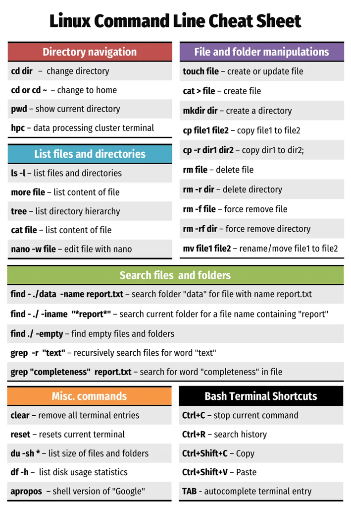

cheatsheet

[interactive chart not shown]